# 431 Class 09

Thomas E. Love, Ph.D.

2026-09-22

## Today’s Agenda

- New Data on European Family Care Givers
- Comparing Working Hours by Education Level
  - One-Way Analysis of Variance
  - Considering an Outcome Transformation in ANOVA
- Correlation and Regression to study burden
  - Fitting a linear model with `lm()`
  - Checking its performance and fit
- **1:45 PM**: Favorite Movies: Session 2

## Load packages and set theme

```r
knitr::opts_chunk$set(comment = NA)

source("c09/data/Love-431.R") # for the lovedist() function

library(janitor)
library(patchwork)
library(DescTools)  ## post-hoc Bonferroni or Tukey HSD
library(naniar)     ## dealing with missing data
library(car)        ## for Box-Cox
library(easystats)
library(tidyverse)

theme_set(theme_lucid())
```

## Get the data

[EUROFAMCARE project](https://www.uke.de/extern/eurofamcare/): a survey on the situation of family carers of older people in Europe.

```r
ecare_raw <- read_csv("c09/data/eurocare.csv", show_col_types = FALSE) |>
  janitor::clean_names() |>
  mutate(across(where(is.character), as_factor)) |>
  mutate(subject = as.character(subject)) |>
  select(subject, hours, c_educ = c_education, neg_impact, pos_impact)

dim(ecare_raw)
```

```
[1] 902   5
```

```r
head(ecare_raw, 3)
```

```
# A tibble: 3 × 5
  subject hours c_educ neg_impact pos_impact
  <chr>   <dbl> <fct>       <dbl>      <dbl>
1 S-0001     16 Middle         12         12
2 S-0002    148 Middle         20         11
3 S-0003     70 Low            11         13
```

## Variable Descriptions

| Variable | Description |
| --- | --- |
| `subject` | carer (care giver) associated with this family |
| `hours` | weekly hours carer spends caring for elder |
| `c_educ` | carer education level (High, Medium, Low) |
| `neg_impact` | COPE Index: carer’s burden: negative impact |
| `pos_impact` | COPE Index: carer’s burden: positive impact |

More on these burden scores later.

## Missingness Assessment

```r
miss_var_summary(ecare_raw)
```

```
# A tibble: 5 × 3
  variable   n_miss pct_miss
  <chr>       <int>    <num>
1 c_educ         60     6.65
2 pos_impact     21     2.33
3 neg_impact     10     1.11
4 subject         0     0
5 hours           0     0
```

```r
miss_case_table(ecare_raw)
```

```
# A tibble: 4 × 3
  n_miss_in_case n_cases pct_cases
           <int>   <int>     <dbl>
1              0     818    90.7
2              1      78     8.65
3              2       5     0.554
4              3       1     0.111
```

## Eliminating Missing Values

Today, we’ll filter to complete cases across the whole data set.

```r
ecare <- ecare_raw |> drop_na()
summary(ecare)
```

```
      subject        hours           c_educ      neg_impact      pos_impact
 Length   :818   Min.   :  4.00   Middle:494   Min.   : 7.00   Min.   : 5.0
 N.unique :818   1st Qu.: 10.00   Low   :175   1st Qu.: 9.00   1st Qu.:11.0
 N.blank  :  0   Median : 20.00   High  :149   Median :11.00   Median :13.0
 Min.nchar:  6   Mean   : 41.58                Mean   :11.82   Mean   :12.5
 Max.nchar:  6   3rd Qu.: 42.00                3rd Qu.:14.00   3rd Qu.:14.0
                 Max.   :168.00                Max.   :28.00   Max.   :16.0
```

Complete case analyses can create problems, but for today, we’ll ignore them.

## `c_educ` is a factor

```r
ecare |> tabyl(c_educ)
```

```
 c_educ   n   percent
 Middle 494 0.6039120
    Low 175 0.2139364
   High 149 0.1821516
```

Put this factor into a more sensible order with `fct_relevel()`

```r
ecare <- ecare |>
  mutate(c_educ =
           fct_relevel(c_educ, "High", "Middle", "Low"))
```

## Automated Codebook

We don’t need to see the subjects list.

```r
data_codebook(ecare |> select(!subject))
```

```
select(ecare, !subject) (818 rows and 4 variables, 4 shown)

ID | Name       | Type        | Missings |   Values |           N
---+------------+-------------+----------+----------+------------
1  | hours      | numeric     | 0 (0.0%) | [4, 168] |         818
---+------------+-------------+----------+----------+------------
2  | c_educ     | categorical | 0 (0.0%) |     High | 149 (18.2%)
   |            |             |          |   Middle | 494 (60.4%)
   |            |             |          |      Low | 175 (21.4%)
---+------------+-------------+----------+----------+------------
3  | neg_impact | numeric     | 0 (0.0%) |  [7, 28] |         818
---+------------+-------------+----------+----------+------------
4  | pos_impact | numeric     | 0 (0.0%) |  [5, 16] |         818
-----------------------------------------------------------------
```

## How do mean `hours` vary by `c_educ`?

```r
ggplot(ecare, aes(y = hours, x = c_educ)) +
  geom_violin(aes(fill = c_educ)) +
  geom_boxplot(width = 0.2) +
  stat_summary(fun = mean, geom = "point",
               shape = 16, size = 3, col = "red") +
  scale_fill_viridis_d(alpha = 0.3) +
  guides(fill = "none")
```

## How do mean `hours` vary by `c_educ`?

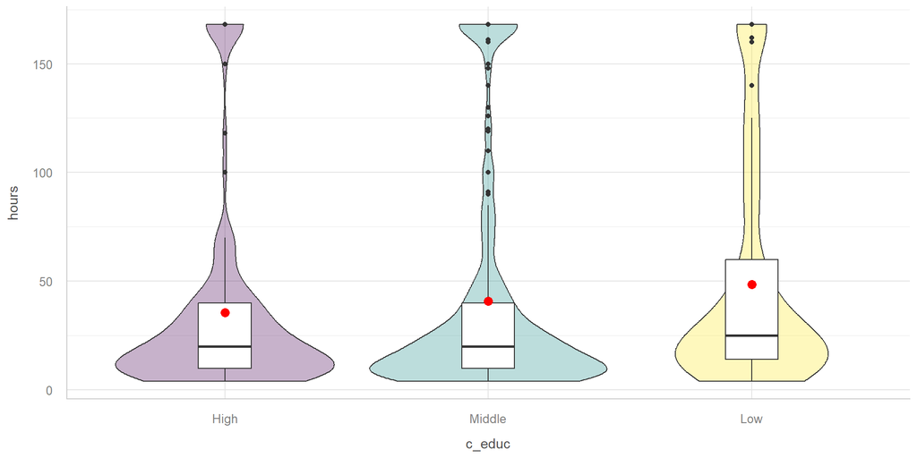

## How do `hours` vary by `c_educ`? (1/2)

```r
ecare |> group_by(c_educ) |> reframe(lovedist(hours))
```

```
# A tibble: 3 × 11
  c_educ     n  miss  mean    sd   med   mad   min   q25   q75   max
  <fct>  <int> <int> <dbl> <dbl> <dbl> <dbl> <dbl> <dbl> <dbl> <dbl>
1 High     149     0  35.5  44.7    20  17.8     4    10    40   168
2 Middle   494     0  40.9  50.7    20  18.5     4    10    40   168
3 Low      175     0  48.6  51.2    25  22.2     4    14    60   168
```

- Sample mean `hours` are somewhat smaller for carers with higher levels of education.
  - Does these mean differences seem meaningful?
  - Does each group’s data follow a Normal distribution?

## Do `hours` vary by `c_educ`? (2/2)

```r
ecare |> group_by(c_educ) |> reframe(lovedist(hours))
```

```
# A tibble: 3 × 11
  c_educ     n  miss  mean    sd   med   mad   min   q25   q75   max
  <fct>  <int> <int> <dbl> <dbl> <dbl> <dbl> <dbl> <dbl> <dbl> <dbl>
1 High     149     0  35.5  44.7    20  17.8     4    10    40   168
2 Middle   494     0  40.9  50.7    20  18.5     4    10    40   168
3 Low      175     0  48.6  51.2    25  22.2     4    14    60   168
```

- What else might we consider here?
  - Do we have a balanced design?
  - Are sample variances very different from each other?

## ANOVA model for this comparison

```r
fit1 <- lm(hours ~ c_educ, data = ecare)
anova(fit1)
```

```
Analysis of Variance Table

Response: hours
           Df  Sum Sq Mean Sq F value  Pr(>F)
c_educ      2   14218  7109.0  2.8706 0.05724 .
Residuals 815 2018305  2476.4
---
Signif. codes:  0 '***' 0.001 '**' 0.01 '*' 0.05 '.' 0.1 ' ' 1
```

```r
model_parameters(fit1, ci = 0.95)
```

```
Parameter       | Coefficient |   SE |         95% CI | t(815) |      p
-----------------------------------------------------------------------
(Intercept)     |       35.53 | 4.08 | [27.53, 43.53] |   8.72 | < .001
c educ [Middle] |        5.40 | 4.65 | [-3.73, 14.53] |   1.16 | 0.246
c educ [Low]    |       13.04 | 5.55 | [ 2.15, 23.93] |   2.35 | 0.019
```

## Plot means with Bonferroni 95% CIs

- Tukey is less appealing in light of unbalanced design.

```r
par(mar=c(3,10,3,3), las = 1)
plot(PostHocTest(aov(fit1), method = "bonferroni", conf.level = 0.95))
```

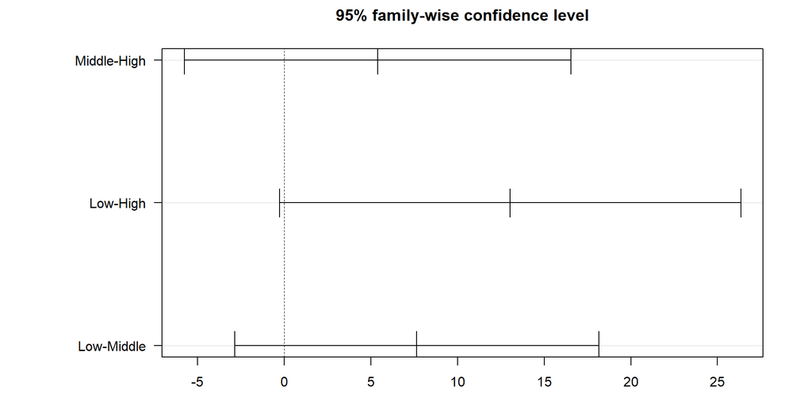

## Does model `fit1` work well?

```r
plot(fit1, which = 2)
```

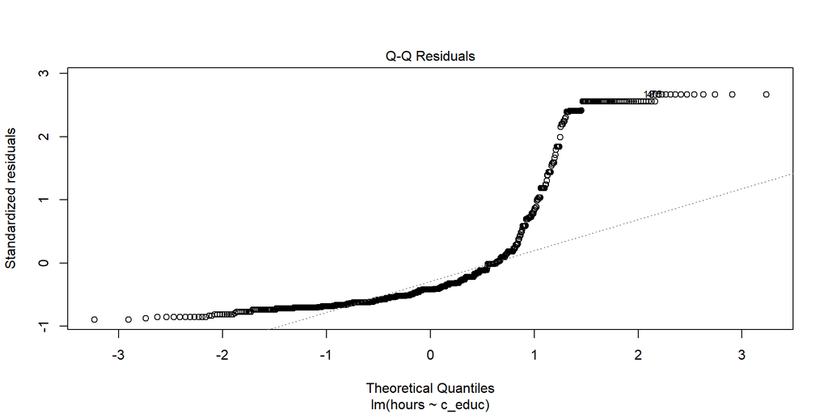

## Could we transform the outcome?

```r
boxCox(fit1)
```

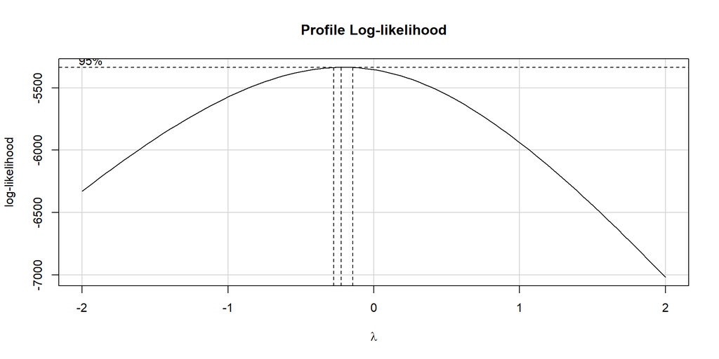

## Impact of log transformation

```r
ecare |> group_by(c_educ) |> reframe(lovedist(log(hours)))
```

```
# A tibble: 3 × 11
  c_educ     n  miss  mean    sd   med   mad   min   q25   q75   max
  <fct>  <int> <int> <dbl> <dbl> <dbl> <dbl> <dbl> <dbl> <dbl> <dbl>
1 High     149     0  3.03 0.993  3.00  1.03  1.39  2.30  3.69  5.12
2 Middle   494     0  3.09 1.09   3.00  1.03  1.39  2.30  3.69  5.12
3 Low      175     0  3.36 1.03   3.22  1.09  1.39  2.64  4.09  5.12
```

```r
ggplot(ecare, aes(y = log(hours), x = c_educ)) +
  geom_violin(aes(fill = c_educ)) +
  geom_boxplot(width = 0.2) +
  stat_summary(fun = mean, geom = "point",
               shape = 16, size = 3, col = "red") +
  scale_fill_viridis_d(alpha = 0.3) +
  guides(fill = "none")
```

## Impact of log transformation

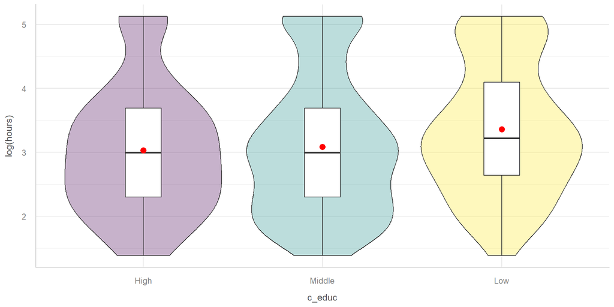

## ANOVA after Transforming `hours`

```r
fit2 <- lm(log(hours) ~ c_educ, data = ecare)

anova(fit2)
```

```
Analysis of Variance Table

Response: log(hours)
           Df Sum Sq Mean Sq F value   Pr(>F)
c_educ      2  11.81  5.9064  5.2668 0.005337 **
Residuals 815 913.98  1.1214
---
Signif. codes:  0 '***' 0.001 '**' 0.01 '*' 0.05 '.' 0.1 ' ' 1
```

- What’s the conclusion here?

## Bonferroni 95% CIs for log(hours)

```r
PostHocTest(aov(fit2), method = "bonferroni", conf.level = 0.95)
```

```
  Posthoc multiple comparisons of means : Bonferroni
    95% family-wise confidence level

$c_educ
                  diff      lwr.ci    upr.ci   pval
Middle-High 0.05805003 -0.17939101 0.2954911 1.0000
Low-High    0.33281527  0.04963222 0.6159983 0.0148 *
Low-Middle  0.27476524  0.05128586 0.4982446 0.0098 **

---
Signif. codes:  0 '***' 0.001 '**' 0.01 '*' 0.05 '.' 0.1 ' ' 1
```

- Variable predicted is actually **log(hours)**

## Bonferroni 95% CIs for log(hours)

```r
par(mar=c(3,10,3,3), las = 1)
plot(PostHocTest(aov(fit2), method = "bonferroni", conf.level = 0.95))
```

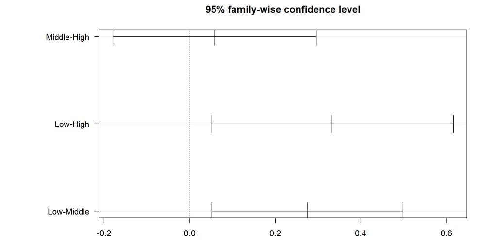

## Normality still a problem?

```r
plot(fit2, which = 2)
```

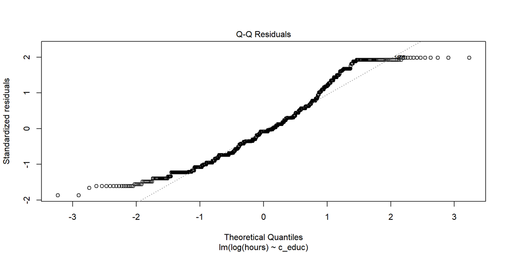

## Kruskal-Wallis ANOVA

If the data were severely skewed, you might try:

```r
kruskal.test(hours ~ c_educ, data = ecare)
```

```
    Kruskal-Wallis rank sum test

data:  hours by c_educ
Kruskal-Wallis chi-squared = 10.622, df = 2, p-value = 0.004938
```

## K Samples: Comparing Means (1)

1. What is the outcome under study?
2. What are the ($K \geq 2$) treatment/exposure groups?
3. Were the data in fact collected using independent samples?
4. Are the data random samples from the population(s) of interest? Or is there at least a reasonable argument for generalizing from the samples to the population(s)?
5. What confidence level do we require?

## K Samples: Comparing Means (2)

6. Are we doing one-sided or two-sided testing? (usually 2-sided)
7. What does the distribution of each individual sample tell us about which inferential procedure to use?
8. Are there meaningful differences between population means?
9. Can we identify pairwise comparisons of means that show meaningful differences using an appropriate procedure that protects against Type I error expansion due to multiple comparisons?

# On to Linear Regression

## Association of Two Quantities

How well can we predict a carer’s negative impact score on the basis of their positive impact score?

- The two scales are described further on the next slide.

```r
ecare |> reframe(lovedist(neg_impact))
```

```
# A tibble: 1 × 10
      n  miss  mean    sd   med   mad   min   q25   q75   max
  <int> <int> <dbl> <dbl> <dbl> <dbl> <dbl> <dbl> <dbl> <dbl>
1   818     0  11.8  3.89    11  2.97     7     9    14    28
```

```r
ecare |> reframe(lovedist(pos_impact))
```

```
# A tibble: 1 × 10
      n  miss  mean    sd   med   mad   min   q25   q75   max
  <int> <int> <dbl> <dbl> <dbl> <dbl> <dbl> <dbl> <dbl> <dbl>
1   818     0  12.5  2.25    13  2.97     5    11    14    16
```

## Caregiver Burden Subscales

- `neg_impact` is higher for carers characterized by avoiding problems, focusing on negative emotions, or engaging in unhealthy behaviors, which are linked to increased psychological distress and other adverse effects.
  - scores in our data range from 7 to 28
- `pos_impact` is higher for carers characterized by adaptive coping strategies focused on finding positive meaning and growth or positive outcomes in stressful situations.
  - scores in our data range from 5 to 16

## Histograms of burden scales

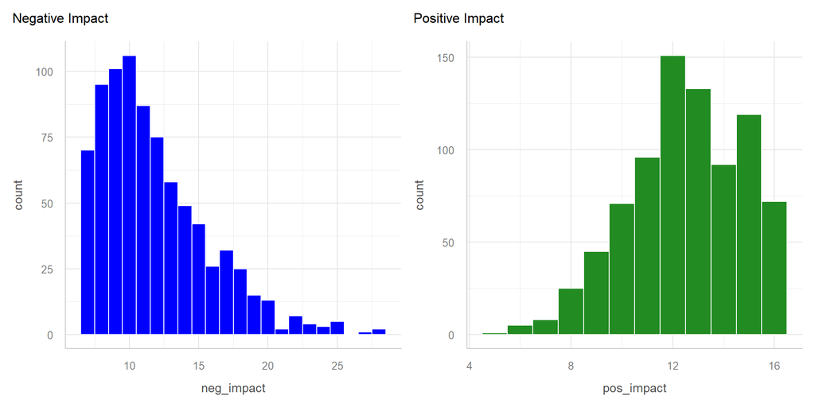

## Scatterplot of 818 Carers

- We’ll plot each point with alpha = 0.3 so that if we have multiple overlapping points, the plot will look darker there.

```r
ggplot(ecare, aes(x = pos_impact, y = neg_impact)) +
  geom_point(alpha = 0.3) +
  geom_smooth(method = "loess",
              formula = y ~ x, se = FALSE, col = "blue") +
  geom_smooth(method = "lm",
              formula = y ~ x, se = TRUE, col = "red") +
  labs(title = "EUROFAMCARE data for 818 subjects",
       x = "Positive Impact Score",
       y = "Negative Impact Score",
       caption = "Linear model in red, loess smooth in blue")
```

## Scatterplot of 818 Carers

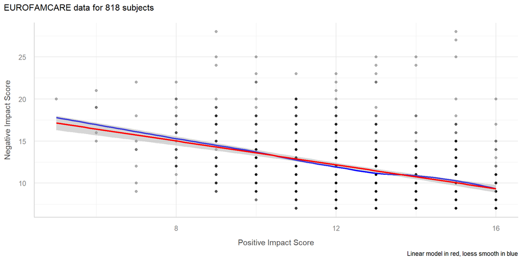

## Jittered Scatterplot

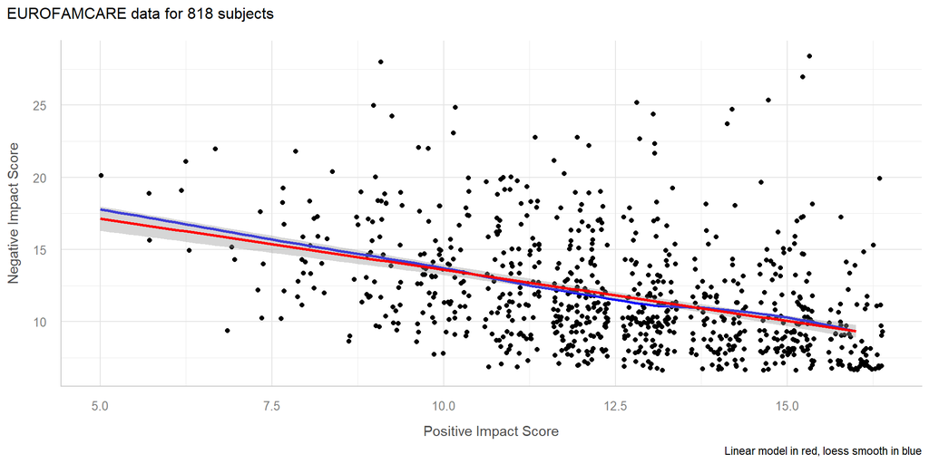

## Pearson Correlation Coefficent

- Pearson r ranges from -1 (perfect inverse relationship: as x goes up, y goes down) to +1 (perfect direct relationship: as x goes up, y goes up.)
- Pearson r measures only a *linear* association.

```r
ecare |> select(neg_impact, pos_impact) |> correlation()
```

```
# Correlation Matrix (pearson-method)

Parameter1 | Parameter2 |     r |         95% CI | t(816) |         p
---------------------------------------------------------------------
neg_impact | pos_impact | -0.41 | [-0.47, -0.35] | -12.86 | < .001***

p-value adjustment method: Holm (1979)
Observations: 818
```

## Considering the Correlation

```r
ecare |> select(neg_impact, pos_impact) |> correlation()
```

```
# Correlation Matrix (pearson-method)

Parameter1 | Parameter2 |     r |         95% CI | t(816) |         p
---------------------------------------------------------------------
neg_impact | pos_impact | -0.41 | [-0.47, -0.35] | -12.86 | < .001***

p-value adjustment method: Holm (1979)
Observations: 818
```

- Is the direction of this correlation surprising?
- How about its magnitude?

## Fit a linear model with OLS

Ordinary Least Squares used to fit a linear model…

```r
fit3 <- lm(neg_impact ~ pos_impact, data = ecare)
model_parameters(fit3, ci = 0.97, pretty_names = FALSE)
```

```
Parameter   | Coefficient |   SE |         97% CI | t(816) |      p
-------------------------------------------------------------------
(Intercept) |       20.69 | 0.70 | [19.17, 22.22] |  29.52 | < .001
pos_impact  |       -0.71 | 0.06 | [-0.83, -0.59] | -12.86 | < .001
```

Note that we’re creating **97%** confidence intervals here.

## Interpreting the intercept

```r
model_parameters(fit3, ci = 0.97, pretty_names = FALSE)
```

```
Parameter   | Coefficient |   SE |         97% CI | t(816) |      p
-------------------------------------------------------------------
(Intercept) |       20.69 | 0.70 | [19.17, 22.22] |  29.52 | < .001
pos_impact  |       -0.71 | 0.06 | [-0.83, -0.59] | -12.86 | < .001
```

- Our `fit3` model estimates the `neg_impact` value to be 20.69 if `pos_impact` = 0.
- All of our `pos_impact` values are between 5 and 16, so we don’t have any useful information about what happens when `pos_impact` = 0, and thus the intercept isn’t actually useful.

## Interpret slope estimate

```r
model_parameters(fit3, ci = 0.97, pretty_names = FALSE)
```

```
Parameter   | Coefficient |   SE |         97% CI | t(816) |      p
-------------------------------------------------------------------
(Intercept) |       20.69 | 0.70 | [19.17, 22.22] |  29.52 | < .001
pos_impact  |       -0.71 | 0.06 | [-0.83, -0.59] | -12.86 | < .001
```

- Suppose Harry’s `pos_impact` is one point larger than Sally’s. Our `fit3` model predicts the `neg_impact` for Harry to be 0.71 points less than that of Sally, on average.
- Of course, this assumes Harry and Sally are similar to the subjects in `ecare` and that our linear model `fit3` is correct.

## Interpret slope’s 97% CI

```r
model_parameters(fit3, ci = 0.97, pretty_names = FALSE)
```

```
Parameter   | Coefficient |   SE |         97% CI | t(816) |      p
-------------------------------------------------------------------
(Intercept) |       20.69 | 0.70 | [19.17, 22.22] |  29.52 | < .001
pos_impact  |       -0.71 | 0.06 | [-0.83, -0.59] | -12.86 | < .001
```

- When we generalize beyond these 818 study participants to the population they were selected at random from, then our data are compatible (at the 97% confidence level) with population slopes between -0.83 and -0.59, depending on the assumptions of our model `fit3` being correct.

## Performance of this model?

```r
model_performance(fit3)
```

```
# Indices of model performance

AIC    |   AICc |    BIC |    R2 | R2 (adj.) |  RMSE | Sigma
------------------------------------------------------------
4396.1 | 4396.2 | 4410.2 | 0.169 |     0.168 | 3.541 | 3.546
```

- $R^2$ tells us model `fit3` accounts for 16.9% of the variation in `neg_impact` we see in these 818 subjects.
- $R^2$ = 0.169 is the square of the Pearson correlation (-0.41) of `neg_impact` and `pos_impact`.
- $\eta^2$ in ANOVA = this $R^2$.

Adjusted $R^2$ will be useful when we have multiple predictors.

## Performance of this model?

```r
model_performance(fit3)
```

```
# Indices of model performance

AIC    |   AICc |    BIC |    R2 | R2 (adj.) |  RMSE | Sigma
------------------------------------------------------------
4396.1 | 4396.2 | 4410.2 | 0.169 |     0.168 | 3.541 | 3.546
```

- About 68% of our predicted `neg_impact` values should be within $\pm 3.546$ points of the correct value, and 95% should be within $\pm 2(3.546)$, or $\pm 7.092$ points.